# Introduction to Spatial Statistics

A Simulation Study: Health Biomarker

Yang Li

2026-05-22

# Simulation

Suppose a public health agency is monitoring a continuous health biomarker, such as an inflammatory marker, air-pollution exposure biomarker, or disease-risk score, across a geographic region. Because it is expensive to collect samples everywhere, measurements are only taken at a limited number of clinics. The goal is to use these observed biomarker values to estimate the spatial pattern of health risk across the entire region.

In this simulation study, we generated data from $n=80$ clinic locations randomly distributed over a $100\times 100$ spatial region. Each clinic represents a sampling site where a health-related biomarker is measured.

The biomarker was assumed to have an overall average level of 10, with spatially correlated variation across the region. This means that clinics located near each other tend to have more similar biomarker values than clinics far apart.

# Load R Packages

```r
library(MASS)
library(sp)
library(gstat)
library(geoR)
```

```r
library(ggplot2)

set.seed(1)
```

Note that `set.seed(1)` is used to make the simulation reproducible in R. Everyone running this code will obtain exactly the same results.

# Simulate Clinic Locations

We simulate 80 clinics whose positions are randomly distributed on a $100\times 100$ region.

```r
n <- 80  # number of clinics

sim_locs <- data.frame(
    clinic_id = 1:n,
    x = runif(n, 0, 100),
    y = runif(n, 0, 100)
)

head(sim_locs)
```

```
##   clinic_id        x        y
## 1         1 26.55087 43.46595
## 2         2 37.21239 71.25147
## 3         3 57.28534 39.99944
## 4         4 90.82078 32.53522
## 5         5 20.16819 75.70871
## 6         6 89.83897 20.26923
```

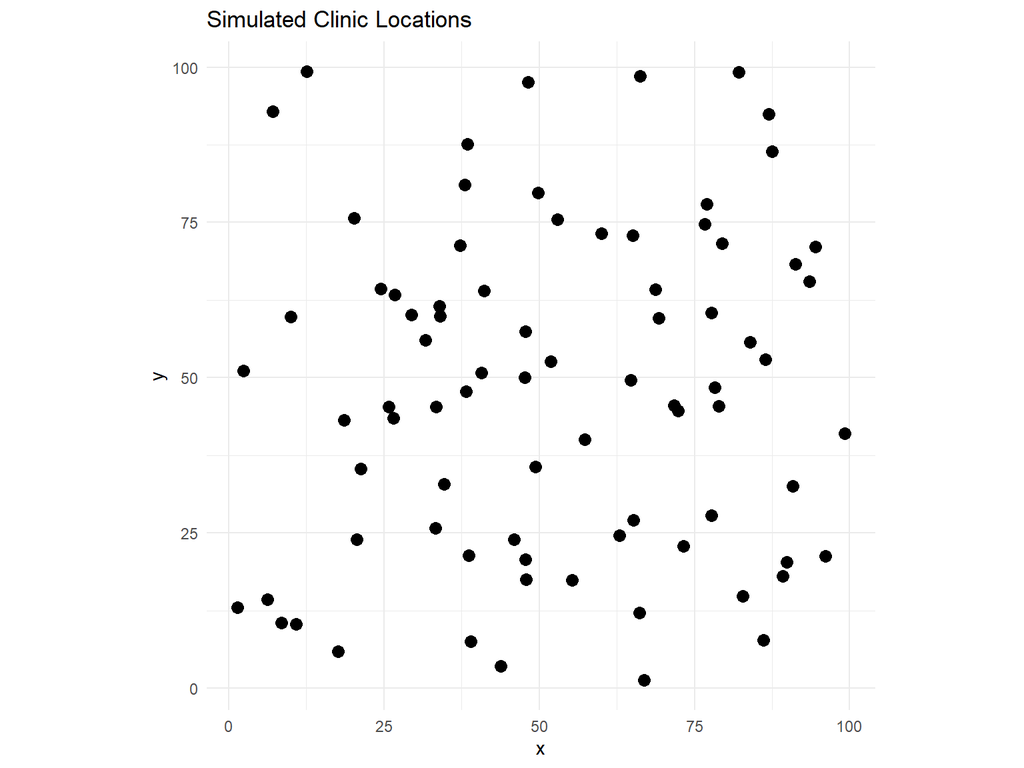

```r
ggplot(sim_locs, aes(x = x, y = y)) +
  geom_point(size = 3, color = "black") +
  coord_equal() +
  labs(
    title = "Simulated Clinic Locations",
    x = "x",
    y = "y"
  ) +
  theme_minimal()
```

# Define a Spatial Covariance Model

We use `grf` function to simulate the data. An exponential covariance function is used.

```r
sim <- grf(
  n = nrow(sim_locs),
  grid = sim_locs[, c('x', 'y')],
  cov.model = "exponential",
  cov.pars = c(4, 25),
  nugget = 0.5,
  mean = 10
)
```

```
## grf: simulation on a set of locations provided by the user
## grf: process with  1  covariance structure(s)
## grf: nugget effect is: tausq= 0.5
## grf: covariance model 1 is: exponential(sigmasq=4, phi=25)
## grf: decomposition algorithm used is:  cholesky
## grf: End of simulation procedure. Number of realizations: 1
```

```r
sim_data <- data.frame(
  x = sim$coords[, 1],
  y = sim$coords[, 2],
  biomarker = sim$data
)

head(sim_data)
```

```
##          x        y biomarker
## 1 26.55087 43.46595  8.793671
## 2 37.21239 71.25147  9.397844
## 3 57.28534 39.99944 12.039947
## 4 90.82078 32.53522  7.285551
## 5 20.16819 75.70871 10.721708
## 6 89.83897 20.26923  9.305285
```

We can visualize the data set by plotting the clinics (dots) on the map. Size and color of the dot represent the measured biomarker value.

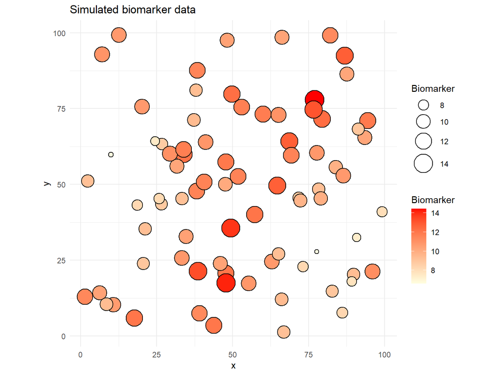

```r
ggplot(sim_data, aes(x = x, y = y, size = biomarker, fill = biomarker)) +
    geom_point(shape = 21, color = "black", stroke = 0.6) +
    scale_size_continuous(range = c(2, 10)) +
    scale_fill_gradient(low = "lightyellow", high = "red") +
    coord_equal() +
    labs(
        title = "Simulated biomarker data",
        x = "x",
        y = "y",
        size = "Biomarker",
        fill = "Biomarker"
    ) +
    theme_minimal()
```

# Plot and Fit the Empirical Variogram

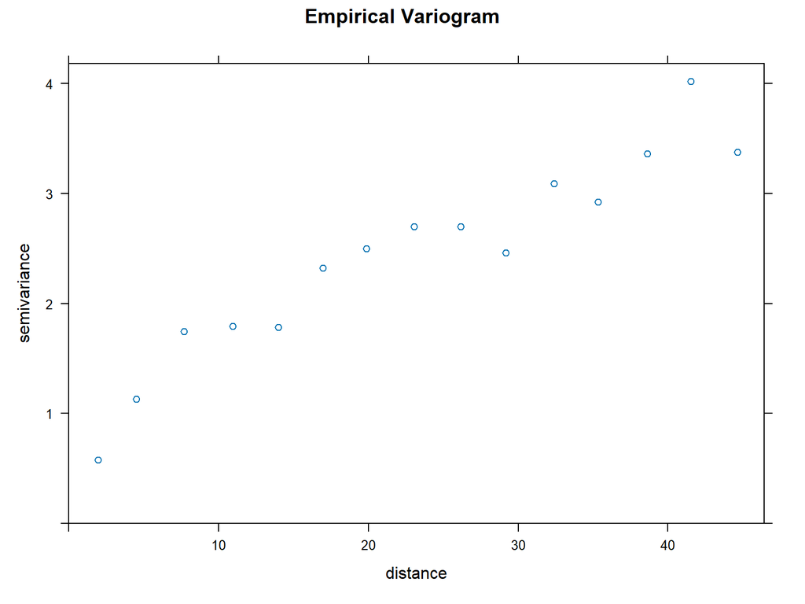

```r
coordinates(sim_data) <- ~ x + y  # convert to a spatial object

emp_vario <- variogram(biomarker ~ 1, data = sim_data)

plot(emp_vario, main = "Empirical Variogram")  # plot the empirical variogram
```

Next, we will fit the empirical variogram.

```r
initial_model <- vgm(
    psill = 4,
    model = "Exp",
    range = 25,
    nugget = 0.5
)

fit_vario <- fit.variogram(emp_vario, initial_model)

fit_vario
```

```
##   model     psill    range
## 1   Nug 0.3320339  0.00000
## 2   Exp 3.1840686 17.33822
```

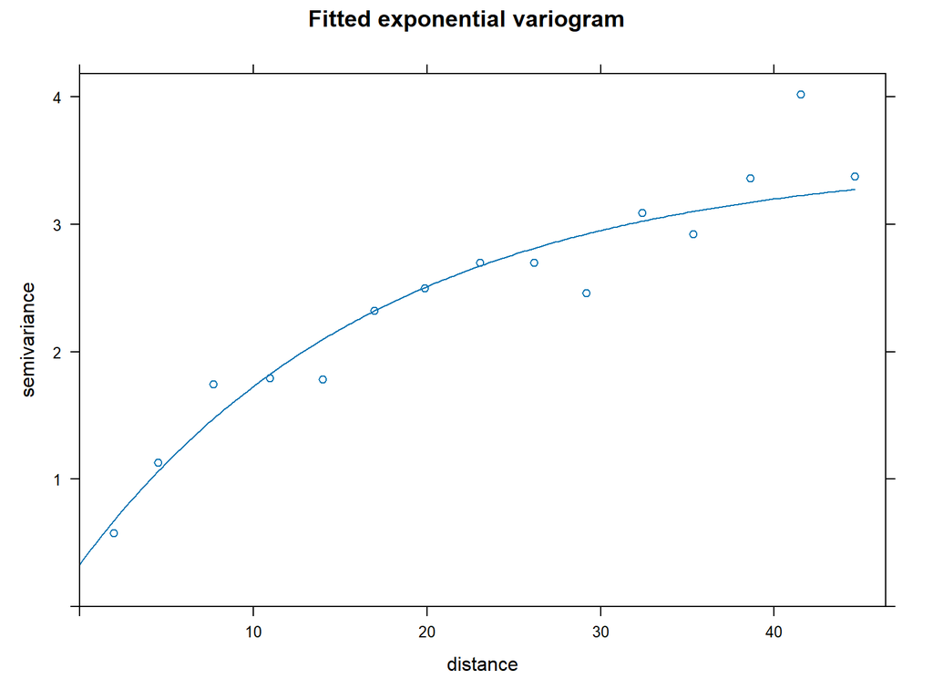

```r
plot(emp_vario, fit_vario, main = "Fitted exponential variogram")
```

# Create Prediction Grid and Do Ordinary Kriging

We make prediction at all lattice points of an $100\times 100$ grid. In total, there are $101\times 101$ predicted values.

```r
grid <- expand.grid(
    x = seq(0, 100, length.out = 101),
    y = seq(0, 100, length.out = 101)
)

coordinates(grid) <- ~ x + y
gridded(grid) <- TRUE
```

We use ordinary kriging to get the predicted values.

```r
ok_result <- krige(
    biomarker ~ 1,
    locations = sim_data,
    newdata = grid,
    model = fit_vario
)
```

```
## [using ordinary kriging]
```

```r
ok_df <- as.data.frame(ok_result)

head(ok_df)
```

```
##   x y var1.pred var1.var
## 1 0 0  10.72792 2.740523
## 2 1 0  10.73096 2.694570
## 3 2 0  10.73506 2.649374
## 4 3 0  10.74132 2.604801
## 5 4 0  10.75107 2.560681
## 6 5 0  10.76567 2.516834
```

# Plot the Predicted Map

We use `geom_raster()` function in `ggplot2` package to draw a rectangular grid of colored cells.

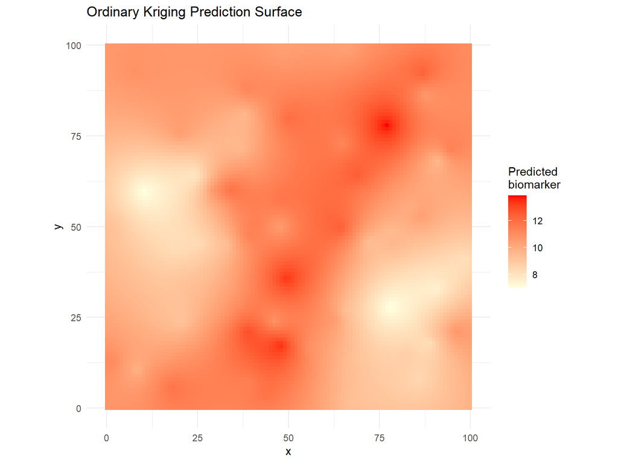

```r
obs_df <- as.data.frame(sim_data)

ggplot() +
    geom_raster(
        data = ok_df,
        aes(x = x, y = y, fill = var1.pred)
    ) +
    scale_fill_gradient(low = "lightyellow", high = "red") +
    coord_equal() +
    labs(
        title = "Ordinary Kriging Prediction Surface",
        x = "x",
        y = "y",
        fill = "Predicted\nbiomarker"
    ) +
    theme_minimal()
```

You can also add the observed values to see their influence.

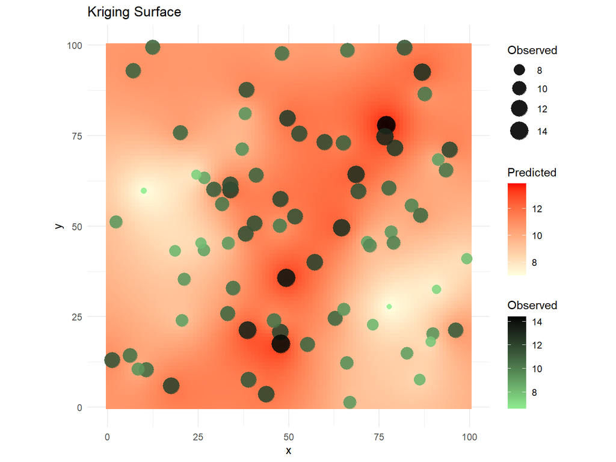

```r
ggplot() +
    geom_raster(
        data = ok_df,
        aes(x = x, y = y, fill = var1.pred)
    ) +
    geom_point(
        data = obs_df,
        aes(x = x, y = y, size = biomarker, color = biomarker),
        alpha = 0.9
    ) +
    scale_size_continuous(range = c(2, 8)) +
    scale_fill_gradient(low = "lightyellow", high = "red") +
    scale_color_gradient(low = "lightgreen", high = "black") +
    coord_equal() +
    labs(
        title = "Kriging Surface",
        x = "x",
        y = "y",
        fill = "Predicted",
        color = "Observed",
        size = "Observed"
    ) +
    theme_minimal()
```

# Plot the map of kriging variance

The **kriging variance** measures the uncertainty of the kriging prediction at each location. A small kriging variance means

- prediction is more reliable, and
- nearby observed data provide strong information.

A large kriging variance means

- prediction is more uncertain, and
- the location is far from observed data or poorly informed.

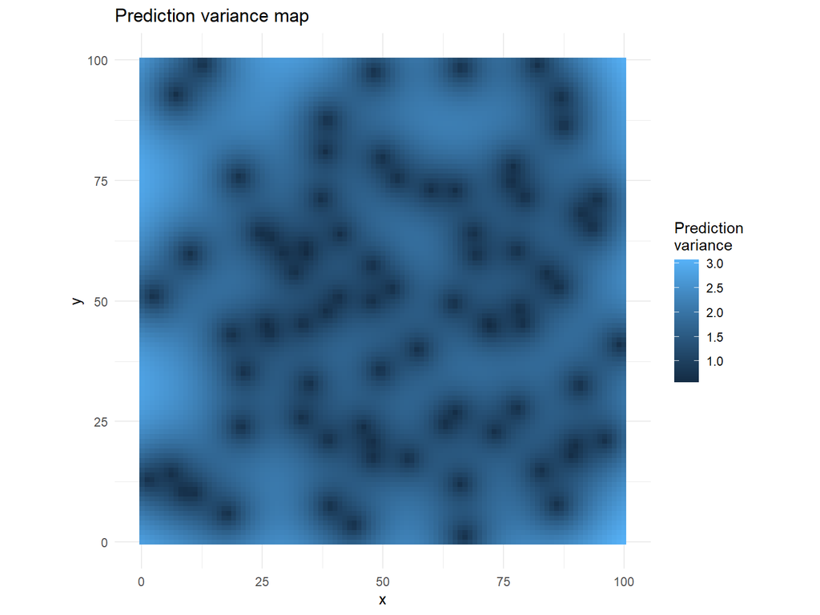

```r
ggplot(ok_df, aes(x = x, y = y, fill = var1.var)) +
  geom_raster() +
  coord_equal() +
  labs(
    title = "Prediction variance map",
    x = "x",
    y = "y",
    fill = "Prediction\nvariance"
  ) +
  theme_minimal()
```